# Election Data

Group 32

5/22/2019

# Summary

# Simple Answers

The total percentage of democratic votes in the 2008 election was **52.93%**

This is the total vote data for our state of Washington:

| total_2008 | dem_2008 | gop_2008 | oth_2008 | total_2012 | dem_2012 | gop_2012 | oth_2012 | total_2016 | dem_2016 | gop_2016 | oth_2016 | state |
| --- | --- | --- | --- | --- | --- | --- | --- | --- | --- | --- | --- | --- |
| 3036878 | 1750848 | 1229216 | 56814 | 2840306 | 1588309 | 1183614 | 68383 | 2765627 | 1523720 | 1043648 | 198259 | WA |

The state that had the maximum democratic votes in 2008 was **California**.

# Correlation

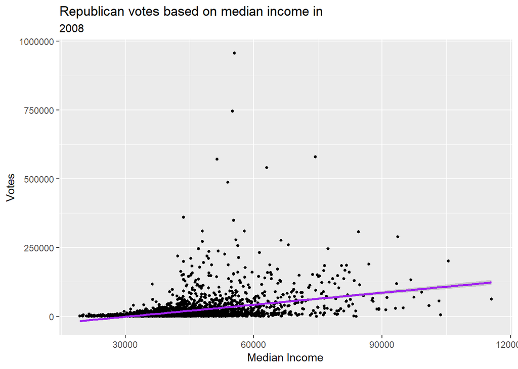

In this scatterplot, we see information regarding the 2008 US Presidential Election. Here, we tried to find a correlation between the median income of voters and the number of Republican votes. Using a line of best fit, we discovered that there is a positive correlation between these two variables. We expect that as median income increases, the number of Republican votes increase.

# Majority

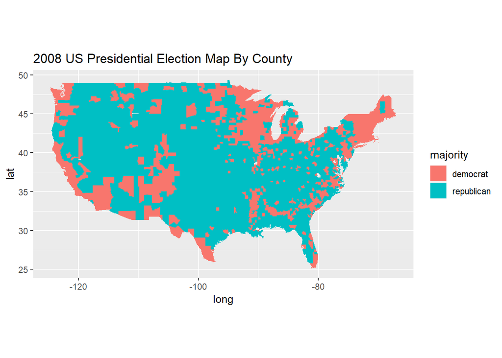

Here, we see some information about the 2008 US Presidential Election. In this map, the red highlights all counties in which the Democratic party was the most popular vote. Also, the blue highlights all counties where the Republican party was the most popular. According to this map diagram, Republican votes dominate the country geographically.